# Inferencia paramétrica

León Berdichevsky Acosta

18 de octubre de 2018

## Estimadores de máxima verosimilitud

Sean $X_1,...,X_n$ las observaciones de una muestra, independientes e idénticamente distribuidas (*i.i.d.*) con función de probabilidad $p(x;\theta)$; esto es $X_1,...,X_n \sim p(x| \theta)$. La función de probabilidad depende de $k$ parámetros $\theta=(\theta_1,...,\theta_k)$ que deamos estimar.

Un estimador $\hat{\theta} = w(X_1,...,X_n)$ es una función de los datos. El método más común para estimar parámetros es el **método de máxima verosimilitud**.

La **función de verosimilitud** se define como:
$$\mathcal{L}(\theta) = \prod_{i=1}^n p(x_i;\theta).$$
La **función log-verosimilitud** se define como
$$\mathcal{l}(\theta)=\log \mathcal{L}(\theta)=\sum_{i=1}^n \log p(x_i; \theta)$$

La función de verosimilitud no es mas que la densidad conjunta de los datos, con la diferencia de que la **tratamos como función del vector de parámetros** $\theta \in \Theta$. Por tanto $\mathcal{L}:\Theta \to [0, \infty)$. En general $\mathcal{L}(\theta)$ no integra a uno respecto a $\theta$.

El **estimador de máxima verosimilitud** es el valor $\hat \theta$ de $\theta$ que maximiza $\mathcal{L}(\theta)$.

El máximo de $\mathcal{l}(\theta)$ se alcanza en el mismo lugar que el máximo de $\mathcal{L}(\theta)$, ya que el logaritmo natural es una función monótona, por lo que maximizar la log-verosimilitud es equivalente a maximizar la verosimilitud.

**Ejemplo:** Distribución Bernoulli. Supongamos que $X_1,...X_n \sim Bernoulli(\theta)$. La función de probabilidad correspondiente es:
$$p(x;\theta)=\theta^x(1-\theta)^{1-x}, \quad x \in \{0,1\}$$

por lo que la función de verosimilitud toma la forma:

$$\mathcal{L}(p)=\prod_{i=1}^n p(x_i;\theta)=\prod_{i=1}^n \theta^{x_i}(1-\theta)^{1-x_i}=\theta^{\sum x_i}(1-\theta)^{n-\sum x_i} = \theta^{S}(1-\theta)^{n-S}$$

donde denotemos como $S=\sum x_i$ al número de éxitos ($x=1$) en la muestra. Entonces, la función log-verosimilitud es:
$$\mathcal{l}(\theta)=S \log \theta + (n-S) \log (1-\theta).$$

Si $n=20$ y $S=12$ tenemos:

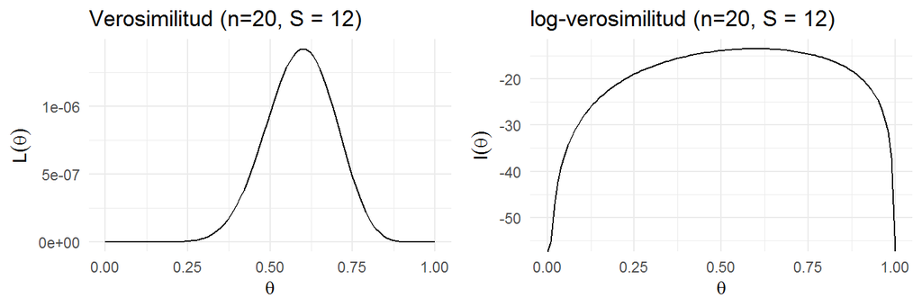

```r
# Verosimilitud X_1,...,X_n ~ Bernoulli(theta)
L_bernoulli <- function(n, S){
    function(theta){
        theta ^ S * (1 - theta) ^ (n - S)
    }
}
# log-verosimilitud
l_bernoulli <- function(n, S){
    function(theta){
        S * log(theta) + (n - S) * log(1 - theta)
    }
}
xy <- data.frame(x = 0:1, y = 0:1)
verosimilitud <- ggplot(xy, aes(x = x, y = y)) +
    stat_function(fun = L_bernoulli(n = 20, S = 12)) +
    xlab(expression(theta)) +
    ylab(expression(L(theta))) +
    ggtitle("Verosimilitud (n=20, S = 12)")

log_verosimilitud <- ggplot(xy, aes(x = x, y = y)) +
    stat_function(fun = l_bernoulli(n = 20, S = 12))+
    xlab(expression(theta)) +
    ylab(expression(l(theta))) +
    ggtitle("log-verosimilitud (n=20, S = 12)")

grid.arrange(verosimilitud, log_verosimilitud, nrow = 1)
```

En ocasiones podemos calcular el estimador de máxima verosimilitud analíticamente:

1. Derivando respecto al vector de parámetros de interés,
2. Igualando a cero el sistema de ecuaciones resultante y despejando los parámetros,
3. Revisando la segunda derivada con respecto al vector de parámetros para asegurar que se encontró un máximo.

En el ejemplo anterior, este proceso permite obtener de manera analítica $\hat{\theta}=S/n$. Con $S=12, n = 20$ obtenemos $\hat{\theta}=0.6$

Cuando no se puedo o es suficientemente complicado obtener una expresión analítica para los estimadores de máxima verosimilitud, se suele recurrir a métodos numéricos de optimización (por ejemplo Newton Raphson, BHHH, DFP). En el caso de R podemos usar las funciones `optim` y `optimize`.

```r
optimize(L_bernoulli(n = 20, S = 12), interval = c(0, 1), maximum = TRUE)
```

```
#> $maximum
#> [1] 0.6
#>
#> $objective
#> [1] 1.43e-06
```

```r
optimize(l_bernoulli(n = 20, S = 12), interval = c(0, 1), maximum = TRUE)
```

```
#> $maximum
#> [1] 0.6
#>
#> $objective
#> [1] -13.5
```

**Ejercicio:** Sean $X_1,...X_n \sim N(\mu, \sigma^2)$:

- Calcule el estimador de máxima verosimilitud para $\theta = (\mu, \sigma^2)$.

Supongamos que $n=100$ y que $\sum_{i=1}^{100} X_i = 40$ y $\sum_{i=1}^{100} X_i^2 = 20$.

- Calcule $\hat{\theta}$ usando el método de máxima verosimilitud.
- Grafique la verosimilitud o log-verosimilitud.

### Propiedades de los estimadores de máxima verosimilitud

Bajo ciertas condiciones del modelo, el estimador de máxima verosimilitud $\hat{\theta}$ tiene propiedades deseables, las principales son:

1. **Consistencia**: $\hat{\theta} \xrightarrow{P} \theta$ (converge en probabilidad), donde $\theta$ es el verdadero valor del parámetro.
2. **Equivarianza**: Si $\hat{\theta}$ es el estimador de máxima verosimilitud de $\theta$, entonces $g(\hat{\theta})$ es el estimador de máxima verosimilitud de $g(\theta)$.

**Ejemplo:** Distribución Binomial. El estimador de máxima verosimilitud del parámetro $p$ es $\hat{p}=\bar{X}$, donde $\bar{X}$ es el promedio de la muestra. Si $\eta=log(p/(1-p)$, entonces el estimador de máxima verosimilitud de $\eta$ es $\hat{\eta}=log(\hat{p}/(1-\hat{p}))$.

3. **Asintóticamente normal**: $\hat{\theta} \to N(\theta, I(\theta)^{-1})$ cuando $n \to \infty$, donde $I(\theta)$ es la **matriz de información** asintótica ($n \to \infty$), la cual definiremos en la siguiente sección.

```r
sim_sigma_hat <- function(n = 50, mu_sim = 0, sigma_sim = 1){
    x <- rnorm(n, mu_sim, sigma_sim)
    sigma_hat <- sqrt(sum((x - mean(x)) ^ 2) / n)
}

sigma_hats <- rerun(1000, sim_sigma_hat(n = 50, mu_sim = 10, sigma_sim = 5)) %>%
    flatten_dbl()

# aprox normal con media theta y error estándar
mean(sigma_hats)
```

```
#> [1] 4.93
```

```r
sd(sigma_hats)
```

```
#> [1] 0.486
```

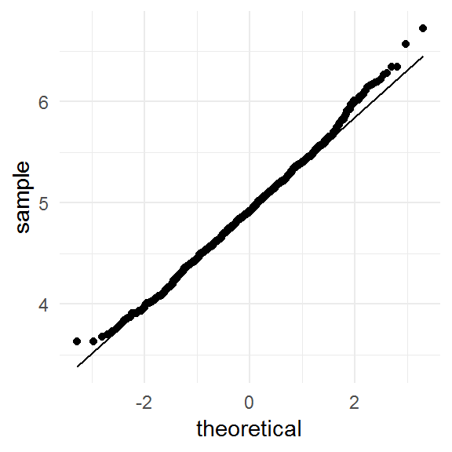

```r
ggplot(data_frame(sigma_hats), aes(sample = sigma_hats)) +
    stat_qq() +
    stat_qq_line()
```

4. **Asintóticamente eficiente**: A grandes razgos, esto quiere decir que del conjunto de estimadores con comportamiento estable, el estimador de máxima verosimilitud tiene la menor varianza cuando $n \to \infty$ (alcanza la cota de Cramer-Rao).

Una vez calculados los estimadores de maxima verosimilitud, el siguiente paso en el proceso de inferencia paramétrica es calcular errores estándar e intervalos de confianza.

### Matriz de información y errores estándar

La matriz Hessiana es la matriz de segundas derivadas de la log-verosimilitud respecto a los parámetros:

$$H(\theta)=\frac{d^2 \mathcal{l}(\theta)}{d\theta d\theta^´}$$
donde $\theta^´$ es el vector de parámetros transpuesto.

La **matriz de información** es el negativo del valor esperado de la matriz Hessiana:

$$I_n(\theta) = - E[H(\theta)]$$

La matriz de varianzas y covarianzas de un vector de estimadores $\hat \theta$ de máxima verosimilitud es igual a la inversa de la matriz de información $I_n(\theta)$:

$$var(\hat \theta)=[I_n(\theta)]^{-1}$$

Entonces, la matriz de varianzas y covarianzas de $\hat{\theta}$ es:

$$var(\hat \theta) = [I_n(\theta)]^{-1} = \big(-E[H(\theta)]\big)^{-1}=\bigg(-E\bigg[\frac{d^2 \mathcal{l}(\theta)}{d\theta d\theta^´}\bigg] \bigg)^{-1}$$

**Ejemplo:** Distribución Bernoulli. La matriz de información (de una dimensión) es $I_n(\theta) = \frac{n}{\theta(1-\theta)}$. Por tanto, la varianza del estimador de máxima verosimilitud es $var(\hat \theta)=\frac{\theta(1-\theta)}{n}$.

¿Porqué se calculan de esta manera los errores estándar?

Idea intuitiva: Podemos pensar que la curvatura de la función de verosimilitud nos dice que tanta certeza tenemos de la estimación de nuestros parámetros. Entre más curva es la función de verosimilitud mayor es la certeza de que hemos estimado el parámetro adecuado. La segunda derivada de la verosimilitud es una medida de la curvatura local de la misma, es por esto que se utiliza para estimar la incertidumbre con la que hemos estimado los parámetros.

**Ejemplo:** Distribución Bernoulli.

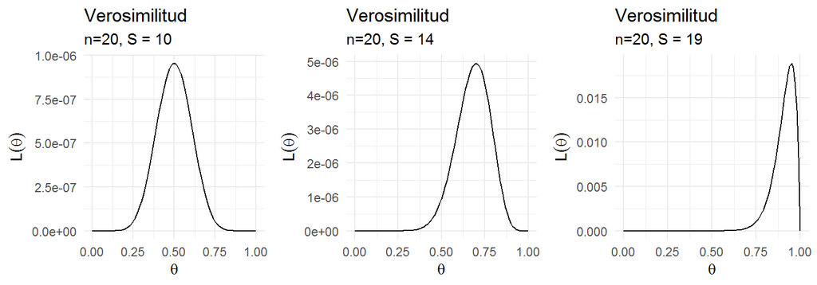

```r
l_b1 <- ggplot(xy, aes(x = x, y = y)) +
    stat_function(fun = L_bernoulli(n = 20, S = 10)) +
    xlab(expression(theta)) +
    ylab(expression(L(theta))) +
    labs(title = "Verosimilitud", subtitle = "n=20, S = 10")
l_b2 <- ggplot(xy, aes(x = x, y = y)) +
    stat_function(fun = L_bernoulli(n = 20, S = 14)) +
    xlab(expression(theta)) +
    ylab(expression(L(theta))) +
    labs(title = "Verosimilitud", subtitle = "n=20, S = 14")
l_b3 <- ggplot(xy, aes(x = x, y = y)) +
    stat_function(fun = L_bernoulli(n = 20, S = 19)) +
    xlab(expression(theta)) +
    ylab(expression(L(theta))) +
    labs(title = "Verosimilitud", subtitle = "n=20, S = 19")

grid.arrange(l_b1, l_b2, l_b3, nrow = 1)
```

Supongamos que el vector de parámetros $\theta$ es de dimensión 1. Cuando $n$ (tamaño de la muestra) es grande, el estimador de máxima verosimilitud $\hat{\theta}$ es aproximadamente Normal, por lo que obtenemos el siguiente resultado:

Bajo condiciones de regularidad apropiadas, se cumple que:

1. Por definición, el error estándar de $\hat \theta$ es $se=\sqrt{1/I_n(\theta)}$. Entonces
   $$\frac{(\hat{\theta} - \theta)}{se} \to N(0, 1), \quad n \to \infty$$
2. Si aproximamos el error estandar de $\hat \theta$ mediante $\hat{se}=\sqrt{1/I_n(\hat{\theta})}$, entonces
   $$\frac{(\hat{\theta} - \theta)}{\hat{se}} \to N(0, 1), \quad n \to \infty$$

El primer enunciado dice que $\hat{\theta}$ se distribuye aproximadamente como $N(\theta,se)$ para $n$ grande. Por su parte el segundo enunciado dice que esto es cierto incluso si reemplazamos el error estándar por su aproximación $\hat{se}=\sqrt{1/I_n(\hat{\theta})}$. Podemos utilizar esta propiedad para construir intervalos de confianza Normales.

La propiedad anterior se puede generalizar al caso en el que el vector de parámetros $\theta$ es de dimensión mayor a 1.

**Ejemplo:** Distribución Bernoulli. Supongamos que $X_1,...X_n \sim Bernoulli(\theta)$. El estimador de máxima verosimilitud es $\hat{\theta}=\sum_{i=1}^n X_i/n$ y un intervalo de confianza de aproximadamante 95% es:
$$\hat{\theta} \pm 1.96 \bigg\{\frac{\hat{\theta}(1- \hat{\theta})}{n} \bigg\}^{1/2}$$